### Estudios de Informática, Multimedia y Telecomunicaciones

# Tipología y Ciclo de Vida de los Datos: PRA2: Limpieza y análisis de datos

James Humberstone, Robinson Cabrera

2023-06-10

# 1 Contexto

Según la Organización Panamericana de la Salud (OPS) cada año mueren más personas por [enfermedades cardiovasculares](https://www.paho.org/es/temas/enfermedades-cardiovasculares) (ECV) que por cualquier otra causa y más de tres cuartas partes de estas muertes ocurren en países de ingresos medianos y bajos.

[Mayo Clinic](https://www.mayoclinic.org/es-es/diseases-conditions/heart-attack/symptoms-causes/syc-20373106) explica en su sitio web que el ataque cardíaco o infarto mediocardio se produce cuando se bloquea o se reduce gravemente el flujo de sangre que va al corazón. Por lo general, la obstrucción se debe la acumulación de grasa, colesterol y otras sustancias en las arterias del corazón (coronarias).

Entre los factores de riesgo se encuentra: la *edad*, la *presión arterial alta*, *niveles elevados de colesterol* y *diabetes*.

Algunos ataques cardíacos se producen de repente. El dolor en el pecho (**angina**) que persiste y no desaparece con el descanso puede ser un signo de alerta temprana. La *angina de pecho* es el resultado de un descenso temporal del flujo sanguíneo hacia el corazón.

Una forma de clasificar los ataques cardíacos es por medio del resultado de un electrocardiograma, si muestra algún cambio específico en la elevación del segmento ST.

Para comprender mejor los factores de riesgo se dará respuesta a las siguientes preguntas de investigación:

## 1.1 Preguntas de investigación.

- ¿Existe una diferencia significativa en la presión arterial entre hombres y mujeres?
- ¿Hay una asociación entre el tipo de angina y el resultado del electrocardiograma?
- ¿El tipo de angina que padece un paciente tiene un efecto en su presión arterial?
- ¿Cómo influyen la edad, el sexo, el colesterol, la presión arterial y la glucemia en los ataques cardíacos?

## 1.2 Presentación del conjunto de datos

El conjunto de datos incluye factores de riesgo de pacientes que tienen una baja o alta probabilidad de padecer ataques cardíacos. El conjunto de datos se encuentra disponible en heart-attack-analysis-prediction-dataset y fue recopilado de la web mediante scrapping por el autor.

```r
#cargamos el conjunto de datos
data<-read.csv("data/heart.csv",header=T,sep=",")
#exploramos el número de observaciones y la cantidad de variables
str(data)
```

```
## 'data.frame':    303 obs. of  14 variables:
##  $ age     : int  63 37 41 56 57 57 56 44 52 57 ...
##  $ sex     : int  1 1 0 1 0 1 0 1 1 1 ...
##  $ cp      : int  3 2 1 1 0 0 1 1 2 2 ...
##  $ trtbps  : int  145 130 130 120 120 140 140 120 172 150 ...
##  $ chol    : int  233 250 204 236 354 192 294 263 199 168 ...
##  $ fbs     : int  1 0 0 0 0 0 0 0 1 0 ...
##  $ restecg : int  0 1 0 1 1 1 0 1 1 1 ...
##  $ thalachh: int  150 187 172 178 163 148 153 173 162 174 ...
##  $ exng    : int  0 0 0 0 1 0 0 0 0 0 ...
##  $ oldpeak : num  2.3 3.5 1.4 0.8 0.6 0.4 1.3 0 0.5 1.6 ...
##  $ slp     : int  0 0 2 2 2 1 1 2 2 2 ...
##  $ caa     : int  0 0 0 0 0 0 0 0 0 0 ...
##  $ thall   : int  1 2 2 2 2 1 2 3 3 2 ...
##  $ output  : int  1 1 1 1 1 1 1 1 1 1 ...
```

**En el conjunto de datos tiene 303 observaciones y 14 variables**. Son 5 variables numéricas (“age”, “trtbps”,“chol”,“thalachh”, “oldpeak”) y 9 variables categóricas (“sex”,“cp”,“fbs”,“restecg”,“exng”,“slp”,“caa”, thall”,“output”), incluyendo la variable de respuesta **output**; por tanto, se pueden aplicar modelos de aprendizaje supervisado, y dado que la variable objetivo es categórica se pueden aplicar algoritmos de clasificación.

```r
#conversión de variables a factor
n <- c("sex","cp","fbs","restecg","exng","slp","thall","output")
data[, n] <- lapply(data[, n], as.factor)
#validación de la transformación
str(data[, n])
```

```
## 'data.frame':    303 obs. of  8 variables:
##  $ sex    : Factor w/ 2 levels "0","1": 2 2 1 2 1 2 1 2 2 2 ...
##  $ cp     : Factor w/ 4 levels "0","1","2","3": 4 3 2 2 1 1 2 2 3 3 ...
##  $ fbs    : Factor w/ 2 levels "0","1": 2 1 1 1 1 1 1 1 2 1 ...
##  $ restecg: Factor w/ 3 levels "0","1","2": 1 2 1 2 2 2 1 2 2 2 ...
##  $ exng   : Factor w/ 2 levels "0","1": 1 1 1 1 2 1 1 1 1 1 ...
##  $ slp    : Factor w/ 3 levels "0","1","2": 1 1 3 3 3 2 2 3 3 3 ...
##  $ thall  : Factor w/ 4 levels "0","1","2","3": 2 3 3 3 3 2 3 4 4 3 ...
##  $ output : Factor w/ 2 levels "0","1": 2 2 2 2 2 2 2 2 2 2 ...
```

Para una mejor compresión de las variables se presenta el diccionario de datos.

## 1.3 Diccionario de datos

El diccionario de datos fue obtenido de la página de inicio del conjunto de datos y de la discusión con ID 234843.

**VARIABLES**

- **age**: Edad del paciente en años.
- **sex**: Sexo del paciente. Variable binaria codificada con los valores 0 (mujer) y 1 (hombre).
- **cp**: Indica el tipo de angina que ha padecido el paciente. Variable categórica con cuatro niveles. **1** indica **angina típica**, **2** indica **angina atípica**, **3** indica **dolor no anginoso** y **0** indica **asintomático**.
- **trtbps**: Presión arterial en reposo (mm Hg) que presentó el paciente al ingresar al hospital.
- **chol**: Cantidad de colesterol del paciente (mg/dl).
- **fbs**: Indica si el paciente tiene azúcar en la sangre. Es el resultado de medir el valor de glucemia en ayuna. Si el valor es mayor a 120, existe azúcar en la sangre. Variable binaria codificada como **0 (falso)** y **1 (verdadero1)**.
- **restecg**: Indica el resultado del electrocardiograma. Variable categórica con tres niveles. **0** indica **normal**, **1** indica **Anomalía de la onda ST-T** y **2** indica **hipertrofia ventricular**.
- **thalachh**: Frecuencia cardíaca máxima alcanzada
- **exng**: Indica si la angina fue inducida por ejercicio. Variable binaria codificada como **0 (falso)** y **1 (verdadero1)**.
- **oldpeak**: Indica la elevación del segmento ST inducida por el ejercicio.
- **slp**: Indica la pendiente de la elevación del segmento ST inducida por el ejercicio. Variable categórica de tres niveles. **0** indica **descendente**, **1** indica **plano** y **2** indica **ascendente**.
- **caa**: Indica el número de arterias coronarias (0-3) que presentan obstrucciones.
- **thall**: Indica el resultado del test de *Thallium Stress*. Variable categórica de tres niveles. **1** indica **defecto fijo**, **2** indica **normal** y **3** indica **defecto reversible**.

**VARIABLE OBJETIVO**

- **output**: Indica la probabilidad de padecer un ataque al corazón. Variable binaria de respuesta codificada con 0 y 1. **0** indica **menor probabilidad de padecer un ataque al corazón** y **1** indica **mayor probabilidad de padecer ataque al corazón**.

# 2 Integración y selección de datos

Para dar respuesta a las preguntas de investigación se creara un subconjunto de datos con las variables a estudiar.

Las variables a utilizar son: *edad*, *sexo*, *tipo de angina*, *presión arterial*, *nivel de colesterol*, *glucemia en la sangre*, *resultado de electrocardiograma*, *número de arterias coronarias obstruidas* y la *variable respuesta*.

```r
library(gmodels)
library(dplyr)
#selección de variables para dar respuesta a las preguntas
variables <- c("age","sex","cp","trtbps","chol","fbs","restecg","caa","output")
misDatos <- data %>% select(all_of(variables))
```

## 2.1 Discretización

Se crearán dos nuevas variables una para clasificar la presión arterial en *Normal (<120)*, *Elevada (120-129)*, *Hipertensión nivel 1 (130-139)*, *Hipertensión nivel 2 (140-180)* y *Crisis de hipertensión (> 180)*. La variable será codificada con los valores de 0 a 4 respectivamente. La clasificación está basada en la American Heart Association obtenidas del siguiente enlace: [Presión arterial nueva clasificación según la AHA](https://yoamoenfermeriablog.com/2018/01/26/presion-arterial-nuevos-valores/)

La otra variable será para clasificar el nivel de colesterol en *deseable (<200)*, *alto (200-239)* y *muy alto (>239)*. La variable se codificará con los valores de 0 a 2 respectivamente. La clasificación se encuentra contenida en el siguiente enlace: [Niveles de colesterol](https://pedromartinnutricion.com/padezco-de-colesterol/)

```r
#creación de variable pa, para clasificar la presión arterial
misDatos$pa <- 0
misDatos$pa[(misDatos$trtbps >= 120 & misDatos$trtbps <= 129)] <- 1
misDatos$pa[(misDatos$trtbps > 129 & misDatos$trtbps <= 139)] <-  2
misDatos$pa[(misDatos$trtbps > 139 & misDatos$trtbps <= 180)]<- 3
misDatos$pa[misDatos$trtbps > 180]<- 4

#creación de variable nc, para clasificar el nivel de colesterol
misDatos$nc <- 0
misDatos$nc[(misDatos$chol >= 200 & misDatos$chol <= 239)] <- 1
misDatos$nc[misDatos$chol > 239] <- 2

#conversión de  nuevas variables a factor
n <- c("pa","nc")
misDatos[, n] <- lapply(misDatos[, n], as.factor)

#muestra aleatoria de 10 registros
set.seed(123)
indices = sample(1:nrow(misDatos),10)
misDatos[indices,c("trtbps","pa","chol","nc")]
```

```
##     trtbps pa chol nc
## 179    120  1  177  0
## 14     110  0  211  1
## 195    140  3  185  0
## 118    120  1  193  0
## 299    140  3  241  2
## 229    170  3  288  2
## 244    152  3  274  2
## 302    130  2  131  0
## 153    170  3  227  1
## 90     100  0  248  2
```

Se actualiza el diccionario de datos con las nuevas variables.

**VARIABLES**

- **pa**: Variable categórica de 5 niveles. Indica si la presión arterial corresponde a: *Normal (0)*, *Elevada (1)*, *Hipertensión nivel 1 (2)*, *Hipertensión nivel 2 (3)* o *Crisis de hipertensión (4)*.
- **nc**: Variable categórica de 3 niveles. Indica si el nivel de colesterol corresponde a: *deseable (0)*, *alto (1)* o *muy alto (2)*.

# 3 Limpieza de datos

## 3.1 Valores atípicos de la variables cuantitativas: *age*, *trtbps*, *chol*, *caa*

A continuación, se revisará la distribución de cada variable para identificar los valores atípicos y determinar si alguno es anómalo. Si el valor es anómalo se marcará como no disponible y se tratará posteriormente.

### 3.1.1 Variable Edad (age)

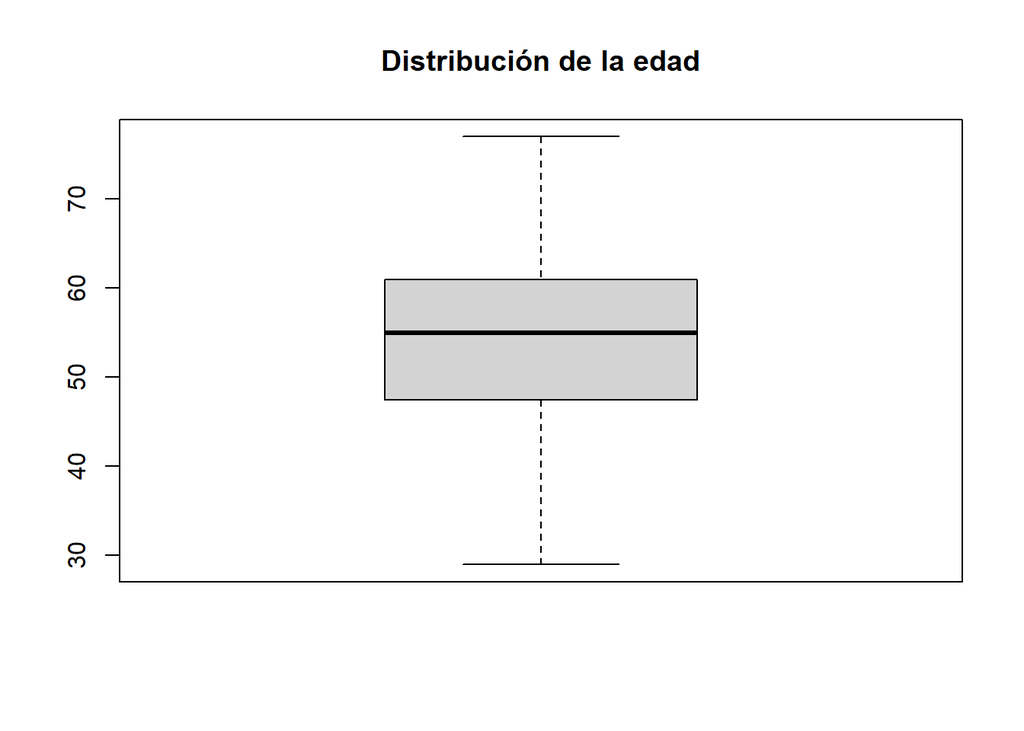

```r
#análisis de la variable age
boxplot(misDatos$age, main="Distribución de la edad")
```

```r
#obtención de los valores atípicos de la variable age
out <- boxplot.stats(misDatos$age)$out
ids <- which(misDatos$age %in% out)
misDatos[ids,"age"]
```

```
## integer(0)
```

**Observación:**

- La variable no tiene valores atípicos.

### 3.1.2 Variable Presión arterial (trtbps)

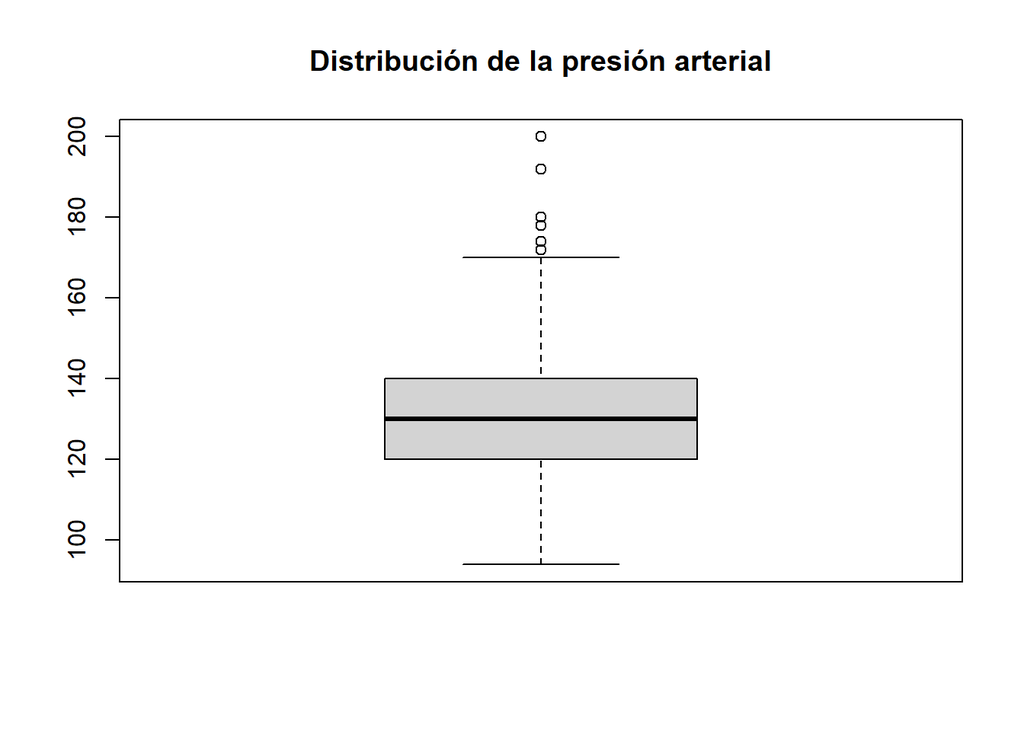

```r
#análisis de la variable trtbps
boxplot(misDatos$trtbps, main="Distribución de la presión arterial")
```

```r
#obtención de los valores atípicos de la variable trtbps
out <- boxplot.stats(misDatos$trtbps)$out
ids <- which(misDatos$trtbps %in% out)
misDatos[ids,"trtbps"]
```

```
## [1] 172 178 180 180 200 174 192 178 180
```

**Observaciones:**

- La variable tiene 9 valores atípicos, pero, **ninguno es un valor anómalo**.
- Según las tablas de presión arterial, los valores mayores a 180 representan una crisis hipertensiva.

### 3.1.3 Variable Colesterol (chol)

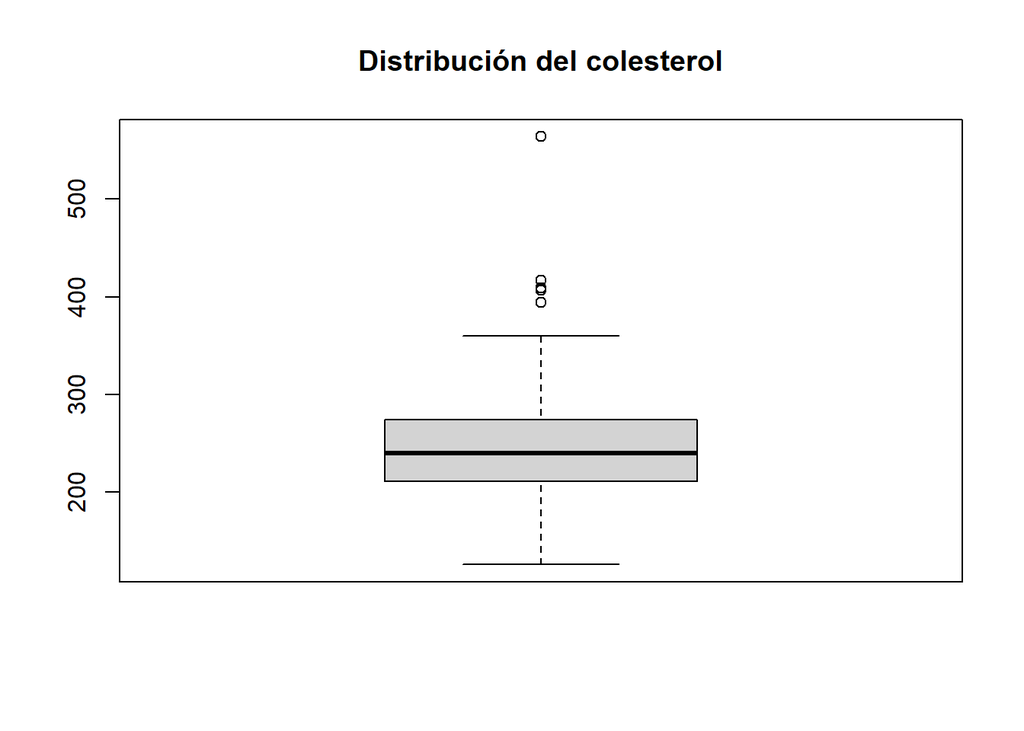

```r
#análisis de la variable chol
boxplot(misDatos$chol, main="Distribución del colesterol")
```

```r
#obtención de los valores atípicos de la variable chol
out <- boxplot.stats(misDatos$chol)$out
ids <- which(misDatos$chol %in% out)
misDatos[ids,"chol"]
```

```
## [1] 417 564 394 407 409
```

**Observaciones:**

- La variable tiene 5 valores atípicos, pero, **ninguno es un valor anómalo**.
- Un valor por encima de 400 representa un trastorno genético, los pacientes sufren hipercolesterolemia aguda y sus niveles de colesterol son superiores a 700.

### 3.1.4 Variable Cantidad de coronarias obstruidas (caa)

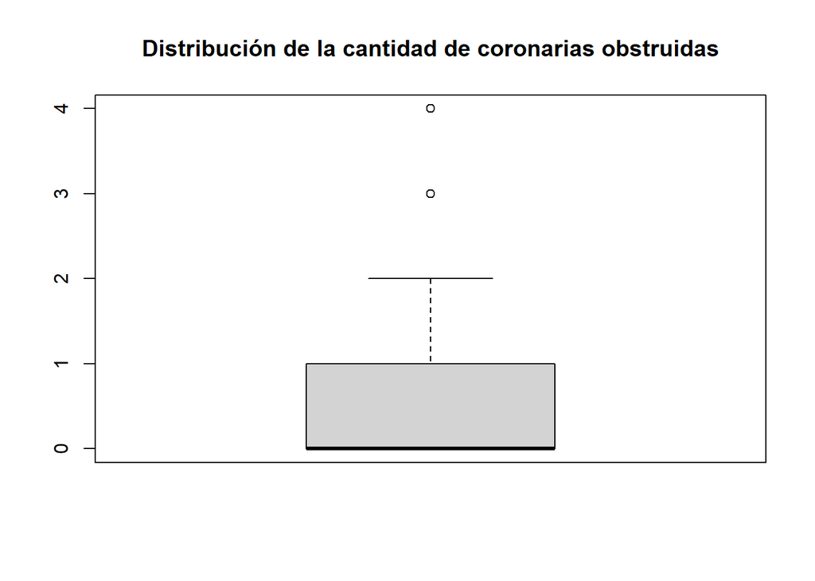

```r
#análisis de la variable caa
boxplot(misDatos$caa, main="Distribución de la cantidad de coronarias obstruidas")
```

```r
#obtención de los valores atípicos de la variable caa
out <- boxplot.stats(misDatos$caa)$out
ids <- which(misDatos$caa %in% out)
misDatos[ids,"caa"]
```

```
##  [1] 3 4 3 3 4 4 4 3 3 3 3 3 3 3 3 3 3 3 3 3 4 3 3 3 3
```

```r
table(misDatos$caa)
```

```
##
##   0   1   2   3   4
## 175  65  38  20   5
```

**Observaciones:**

- El corazón tiene **3** arterias coronarias: *coronaria derecha*, *coronaria izquierda* e *interventricular anterior*; por tanto, valores mayores a 3 se consideran anómalos.
- La variable tiene *5 registros anómalos* ya que presentan un valor de 4, siendo el máximo posible 3.

### 3.1.5 Transformación de valores anómalos a nulos

```r
#transformar datos anómalos en NA para la variable caa
misDatos$caa[misDatos$caa > 3] <- NA
#verificación
summary(misDatos$caa)
```

```
##    Min. 1st Qu.  Median    Mean 3rd Qu.    Max.    NA's
##  0.0000  0.0000  0.0000  0.6745  1.0000  3.0000       5
```

```r
table(misDatos$caa)
```

```
##
##   0   1   2   3
## 175  65  38  20
```

## 3.2 Imputación de valores nulos

```r
#Contabilizar la cantidad de valores nulos en las variables
colSums(is.na(misDatos))
```

```
##     age     sex      cp  trtbps    chol     fbs restecg     caa  output      pa
##       0       0       0       0       0       0       0       5       0       0
##      nc
##       0
```

**observación**

- Se observa que la variable *caa* tiene 5 valores nulos.

**Para la imputación de los valores se hará uso del algoritmo *kNN* del paquete *VIM*.**

```r
#obtenemos los índices de los registros que tienen valores nulos en caa
idsNA <- which(is.na(misDatos$caa))
misDatos[idsNA,] #impresión de los registros previo a la imputación
```

```
##     age sex cp trtbps chol fbs restecg caa output pa nc
## 93   52   1  2    138  223   0       1  NA      1  2  1
## 159  58   1  1    125  220   0       1  NA      1  1  1
## 164  38   1  2    138  175   0       1  NA      1  2  0
## 165  38   1  2    138  175   0       1  NA      1  2  0
## 252  43   1  0    132  247   1       0  NA      0  2  2
```

```r
if (!require(VIM)) install.packages("VIM")
#imputación
datos.sin.NA <-kNN(misDatos, variable="caa", k=11)
misDatos[idsNA,]$caa <- datos.sin.NA[datos.sin.NA$caa_imp == TRUE,]$caa
#validación de la transformación
misDatos[idsNA,]
```

```
##     age sex cp trtbps chol fbs restecg caa output pa nc
## 93   52   1  2    138  223   0       1   0      1  2  1
## 159  58   1  1    125  220   0       1   0      1  1  1
## 164  38   1  2    138  175   0       1   0      1  2  0
## 165  38   1  2    138  175   0       1   0      1  2  0
## 252  43   1  0    132  247   1       0   1      0  2  2
```

```r
#Contabilizar la cantidad de valores nulos en las variables
colSums(is.na(misDatos))
```

```
##     age     sex      cp  trtbps    chol     fbs restecg     caa  output      pa
##       0       0       0       0       0       0       0       0       0       0
##      nc
##       0
```

**observación**

- Se observa que la variable *caa* luego de haber implementado el algoritmo kn no presenta valores nulos.

# 4 Análisis de los datos

## 4.1 Estudio descriptivo

Para tener una mejor compresión de los datos se graficarán las variables respecto a la variable objetivo.

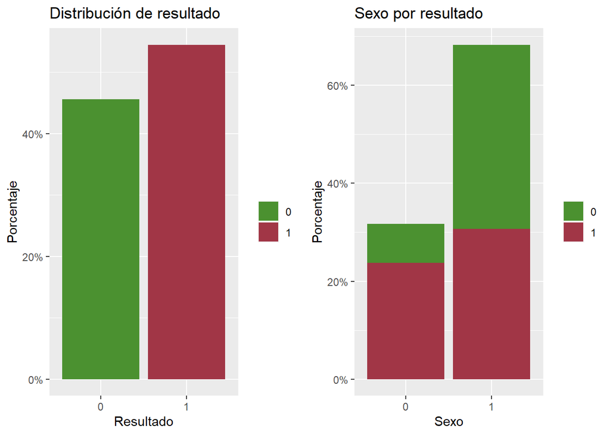

```r
library(ggplot2)
library(grid)
library(gridExtra)


grid.newpage()

g1 <- ggplot(misDatos,aes(output, fill=output))+geom_bar(aes(y = (..count..)/sum(..count..))) + scale_y_continuous(labels=scales::percent) + labs(x="Resultado", y="Porcentaje") + guides(fill=guide_legend(title="")) + scale_fill_manual(values=c("#4b9130","#a13646")) + ggtitle("Distribución de resultado")

g2 <- ggplot(misDatos,aes(sex,fill=output))+ geom_bar(aes(y = (..count..)/sum(..count..))) + scale_y_continuous(labels=scales::percent) + labs(x="Sexo", y="Porcentaje")+ guides(fill=guide_legend(title="")) + scale_fill_manual(values=c("#4b9130","#a13646"))  + ggtitle("Sexo por resultado")

grid.arrange(g1,g2,ncol=2)
```

**Observaciones:**

- La **variable respuesta (output)** se encuentra desbalanceada, tiene 45% de observaciones con 0 y 55% de observaciones con 1.
- La variable **sex** tiene una distribución de: *32% mujeres* y *68% hombres*.
- El *75% de las mujeres* tiene una alta probabilidad de sufrir ataques cardíacos, mientras que los hombres que también tienen una alta probabilidad de sufrirlo representan el *45%*.

Continuamos observando las distribución de las variables *cp* y *fbs*.

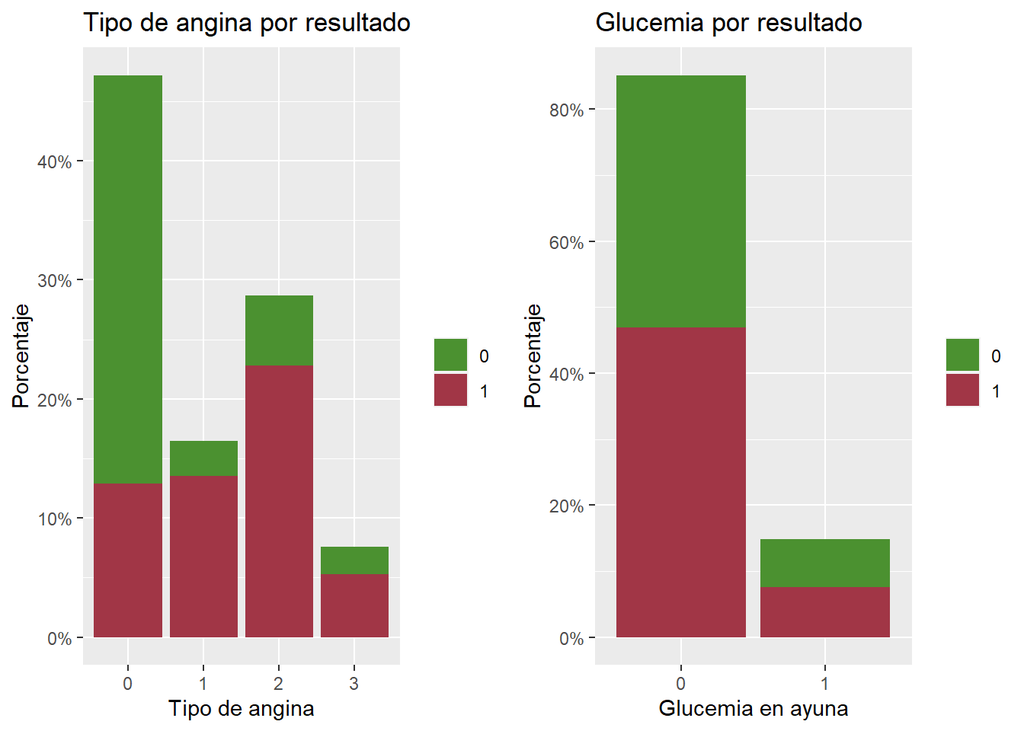

```r
g3 <- ggplot(misDatos,aes(cp,fill=output)) + geom_bar(aes(y = (..count..)/sum(..count..))) + scale_y_continuous(labels=scales::percent) + labs(x="Tipo de angina", y="Porcentaje")+ guides(fill=guide_legend(title="")) + scale_fill_manual(values=c("#4b9130","#a13646")) + ggtitle("Tipo de angina por resultado")

g4 <- ggplot(misDatos,aes(fbs,fill=output)) + geom_bar(aes(y = (..count..)/sum(..count..))) + scale_y_continuous(labels=scales::percent) + labs(x="Glucemia en ayuna", y="Porcentaje") + guides(fill=guide_legend(title="")) + scale_fill_manual(values=c("#4b9130","#a13646")) + ggtitle("Glucemia por resultado")

grid.arrange(g3,g4,ncol=2)
```

Continuamos observando las distribuciones de las variables *restecg* y *caa*.

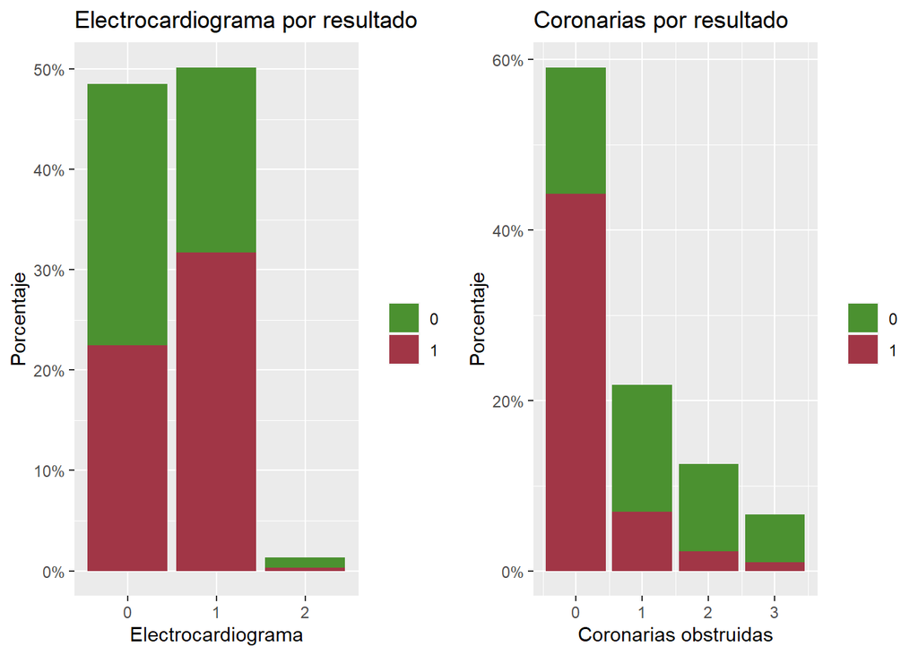

```r
g5 <- ggplot(misDatos,aes(restecg,fill=output))+geom_bar(aes(y = (..count..)/sum(..count..))) + scale_y_continuous(labels=scales::percent) + labs(x="Electrocardiograma", y="Porcentaje") + guides(fill=guide_legend(title="")) + scale_fill_manual(values=c("#4b9130","#a13646")) + ggtitle("Electrocardiograma por resultado")

g6 <- ggplot(misDatos,aes(caa,fill=output))+geom_bar(aes(y = (..count..)/sum(..count..))) + scale_y_continuous(labels=scales::percent) + labs(x="Coronarias obstruidas", y="Porcentaje") + guides(fill=guide_legend(title="")) + scale_fill_manual(values=c("#4b9130","#a13646")) + ggtitle("Coronarias por resultado")

grid.arrange(g5,g6,ncol=2)
```

**Observaciones:**

- La distribución de la variable **Resultado del electrocardiograma (restecg)** es *48% normal*, *50% Anomalía de la onda ST-T* y *2% hipertrofia ventricular*.
- El *45% de los pacientes con resultado normal* tienen alta posibilidad de sufrir ataques cardíacos, aproximadamente el *60% de los pacientes con anomalía de la onda ST-T* tienen alta probabilidad de sufrirlos y un *25% de pacientes con hipertrofia ventricular* también tienen alta probabilidad de sufrirlos.
- La distribución de la variable **arterias coronarias obstruidas (caa)** es *59% pacientes sin obstrucción en las coronarias*, *21% pacientes con una coronaria obstruida*, *13% pacientes con dos coronarias obstruidas* y *7% con tres coronarias obstruidas*.
- El *70% de los pacientes sin obstrucción en las coronarias* tiene alta probabilidad de sufrir ataques cardíacos y *menos del 30% de los pacientes con una o más coronarias obstruidas* también tienen alta posibilidad de sufrirlos. **Este resultado es contrario a lo que se espera, ya que los pacientes sin obstrucción tienen mayor probabilidad de padecer el ataque cardíaco que los que tienen una o más coronarias obstruidas.**

Continuamos observando las distribuciones de las variables *age* y *trtbps*.

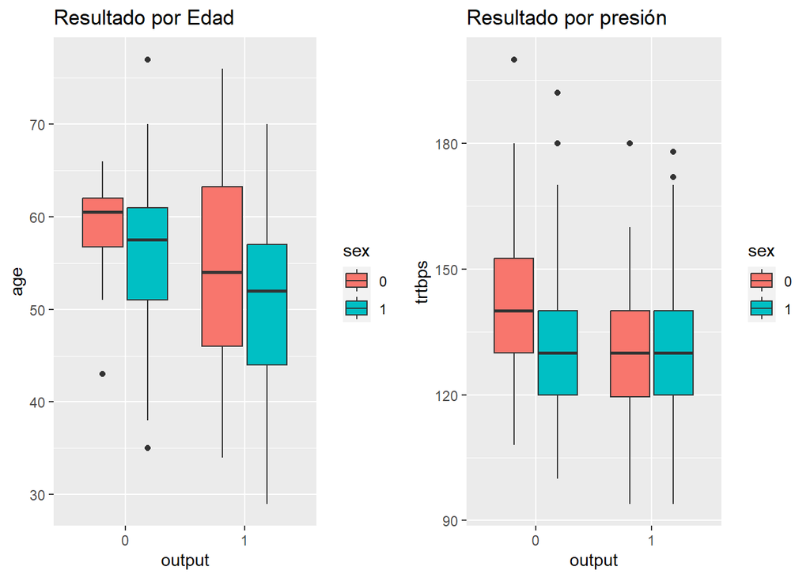

```r
g7 <- ggplot(misDatos, aes(x=output, y=age, fill=sex))+ geom_boxplot() + ggtitle("Resultado por Edad")

g8 <- ggplot(misDatos, aes(x=output, y=trtbps, fill=sex))+ geom_boxplot() + ggtitle("Resultado por presión")

grid.arrange(g7,g8,ncol=2)
```

**Observaciones:**

Continuamos observando las distribución de la variable *chol*.

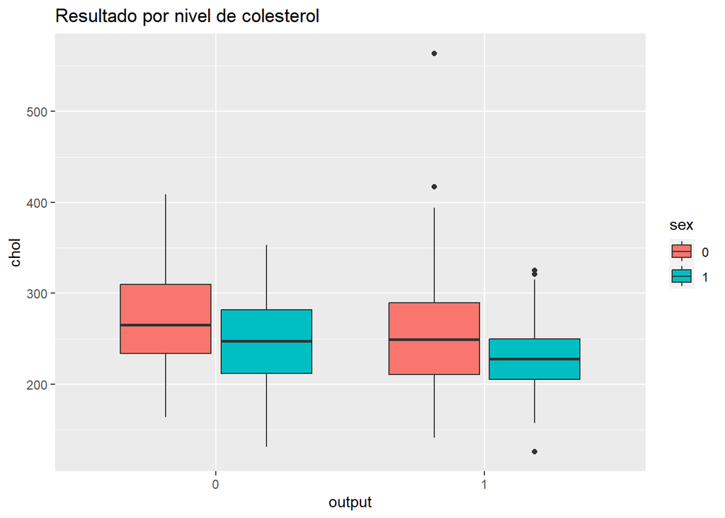

```r
ggplot(misDatos, aes(x=output, y=chol, fill=sex)) + geom_boxplot() + ggtitle("Resultado por nivel de colesterol")
```

**Observaciones:**

- Las mujeres presentan un nivel de colesterol más alto que los hombres.
- La distribución del nivel de colesterol de las mujeres tiene mayor variabilidad que la de los hombres.

Finalmente, se observará la distribución de las variables discretizadas *pa* y *nc*

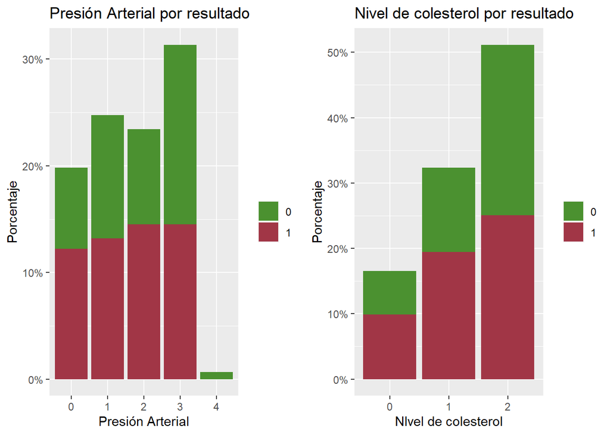

```r
g9 <- ggplot(misDatos,aes(pa,fill=output))+geom_bar(aes(y = (..count..)/sum(..count..))) + scale_y_continuous(labels=scales::percent) + labs(x="Presión Arterial", y="Porcentaje") + guides(fill=guide_legend(title="")) + scale_fill_manual(values=c("#4b9130","#a13646")) + ggtitle("Presión Arterial por resultado")

g10 <- ggplot(misDatos,aes(nc,fill=output))+geom_bar(aes(y = (..count..)/sum(..count..))) + scale_y_continuous(labels=scales::percent) + labs(x="NIvel de colesterol", y="Porcentaje") + guides(fill=guide_legend(title="")) + scale_fill_manual(values=c("#4b9130","#a13646")) + ggtitle("Nivel de colesterol por resultado")

grid.arrange(g9,g10,ncol=2)
```

## 4.2 Diferencia entre la presión arterial de hombres y mujeres

Sea $\mu_h$ la media de la presión arterial en los hombres y $\mu_m$ en las mujeres, la hipótesis nula ($H_0$) y alternativa ($H_1$) son:

- $H_0$ = $\mu_h$ $=$ $\mu_m$
- $H_1$ = $\mu_h$ $\neq$ $\mu_m$

A continuación, se evaluará la normalidad de los datos.

```r
#presión arterial de las mujeres
paM = misDatos$trtbps[misDatos$sex == 0]
#presión arterial de los hombres
paH = misDatos$trtbps[misDatos$sex == 1]
#impresión del número de observaciones
c(length(paM), length(paH))
```

```
## [1]  96 207
```

**observaciones:**

- Las muestras tienen 96 y 207 datos respectivamente, por tanto; **son muestras grandes (mayores a 30) y al aplicar el Teorema del límite central concluimos que las dos muestras siguen un distribución normal.**
- Debido a la normalidad de los datos se debe aplicar un **test paramétrico**.

**Evaluación de la homoscedasticidad**. Sea $\sigma_H^2$ la varianza de la presión arterial para los hombres y $\sigma_M^2$ para las mujeres, hipótesis nula ($H_0$) y alternativa ($H_1$) son:

- $H_0$: $\sigma_H^2$ $=$ $\sigma_M^2$
- $H_1$: $\sigma_H^2$ $\neq$ $\sigma_M^2$

```r
var.test(paH, paM)
```

```
##
##  F test to compare two variances
##
## data:  paH and paM
## F = 0.74412, num df = 206, denom df = 95, p-value = 0.08328
## alternative hypothesis: true ratio of variances is not equal to 1
## 95 percent confidence interval:
##  0.5209526 1.0394994
## sample estimates:
## ratio of variances
##          0.7441212
```

**observaciones:**

- El **f observado** es 0.74412 y cae dentro de la región de aceptación para la razón de varianzas [0.52095, 1.03949], por tanto, se debe aceptar la hipótesis nula.
- El **valor p** del estadístico de prueba es **0.08328**, es mayor al nivel de significancia (0.05) por lo que no hay evidencia para rechazar la hipótesis nula. Por tanto, se concluye que **las varianzas son iguales** con un nivel de confianza del 95%.

> Para comprobar la diferencia entre la presión arterial de hombres y mujeres se realizará un contraste de medias bilateral entre dos muestras independientes con varianzas desconocidas pero iguales.

```r
t.test(paH,paM,var.equal=TRUE)
```

```
##
##  Two Sample t-test
##
## data:  paH and paM
## t = -0.98649, df = 301, p-value = 0.3247
## alternative hypothesis: true difference in means is not equal to 0
## 95 percent confidence interval:
##  -6.398354  2.125407
## sample estimates:
## mean of x mean of y
##  130.9469  133.0833
```

**observaciones:**

- El **t observado** es -0.98649 y cae dentro de la región de aceptación [-6.39835, 2.1254], por tanto, se debe aceptar la hipótesis nula.
- El **valor p** del estadístico de prueba es **0.3247**, es mayor al nivel de significancia (0.05) por lo que no hay evidencia para rechazar la hipótesis nula. Por tanto, se concluye que **las medias de la presión arterial son iguales** con un nivel de confianza del 95%.

> Se reafirma que no existe diferencia significativa en la presión arterial entre hombres y mujeres, tal como se observó en el grafico titulado *Resultado por presión*.

## 4.3 Asociación entre el tipo de angina y el resultado del electrocardiograma

Se realizará un contraste de hipótesis de datos categóricos.

Sea $H_0$ la hipótesis nula y $H_1$ la hipótesis alternativa, tenemos:

- $H_0$: el tipo de angina y el resultado del electrocardiograma son variables independientes
- $H_1$: existe una relación entre el tipo de angina y el resultado del electrocardiograma.

Primero se creará una tabla de contingencia entre las dos variables, luego se aplicará la función **chisq.test** que realiza las siguientes tareas:

- Calcula los valores esperados para cada celda de la tabla bajo la suposición de independencia.
- Calcula: el estadístico de chi-cuadrado, los grados de libertad y el valor p

```r
#creación de la tabla de contingencia.
t <- table(misDatos$cp, misDatos$restecg)
#impresión de la tabla
t
```

```
##
##      0  1  2
##   0 78 62  3
##   1 19 31  0
##   2 36 50  1
##   3 14  9  0
```

```r
#contraste de variables categóricas
chisq.test(t, correct = TRUE)
```

```
##
##  Pearson's Chi-squared test
##
## data:  t
## X-squared = 9.6878, df = 6, p-value = 0.1384
```

**Observaciones:**

- El **chi observado** es 9.6878 y los grados de libertad son 6.
- El **valor p** del estadístico de prueba es **0.1384**, es mayor al nivel de significancia (0.05) por lo que no hay evidencia para rechazar la hipótesis nula. Por tanto, se concluye que **las variables son independientes** con un nivel de confianza del 95%.

> No existe asociación entre el tipo de angina y el resultado del electrocardiograma.

## 4.4 ¿El tipo de angina que padece un paciente tiene un efecto en su presión arterial?

Sea $\mu_0$ … $\mu_3$ la presión arterial de los pacientes según el tipo de angina que padece, la hipótesis nula ($H_0$) y alternativa ($H_1$) son:

- $H_0$: $\mu_0 = \mu_1 = \mu_2 = \mu_3 = 0$
- $H_1$: $\mu_i \neq \mu_j$ para algún $i \neq j$

Para poder aplicar un análisis ANOVA es necesario que se cumpla la normalidad y la homocedasticidad en los datos. En caso contrario se debe aplicar un test no paramétrico basado en rangos.

**Evaluado la normalidad de los datos**

```r
#revisando la cantidad de datos para clase
d1 <- misDatos$trtbps[misDatos$cp==0]
d2 <- misDatos$trtbps[misDatos$cp==1]
d3 <- misDatos$trtbps[misDatos$cp==2]
d4 <- misDatos$trtbps[misDatos$cp==3]
#impresión del número de datos por clase.
c(length(d1),length(d2),length(d3),length(d4))
```

```
## [1] 143  50  87  23
```

**Observación**

- Los datos correspondientes a las clases: *asintomático*, *angina típica* y *angina atípica* presentan normalidad por el Teorema del Límite Central. Sin embargo, debemos evaluar la normalidad en el conjunto de datos *dolor no anginoso*.

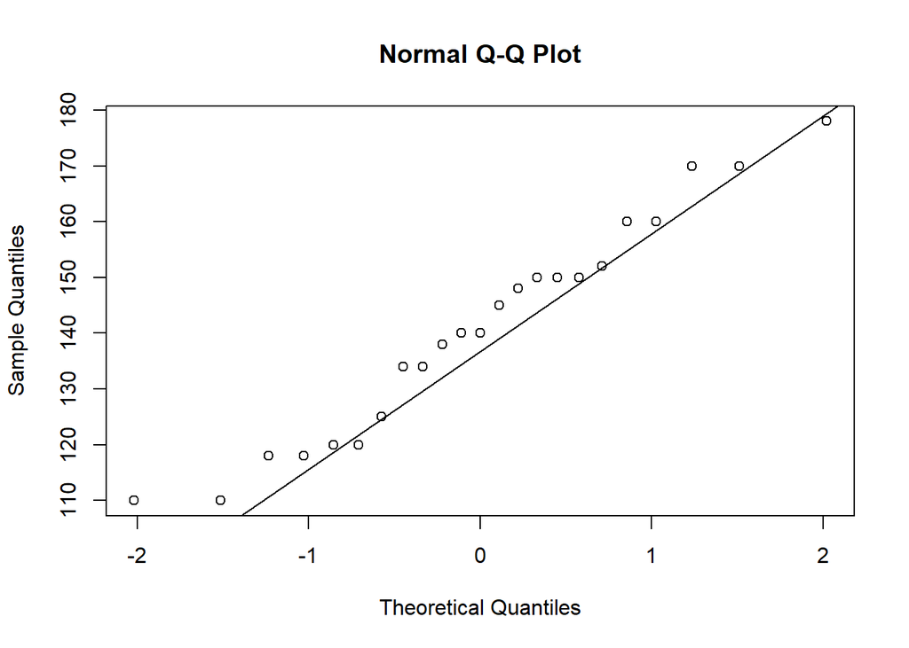

```r
#evaluando normalidad en dolor no anginoso
qqnorm(d4)
qqline(d4)
```

**Observación**

- El gráfico Q-Q muestra que los datos están ligeramente desviados de la línea de referencia. Para mayor certeza se realizará el **test de Shapiro** sobre los datos.

```r
#aplicamos el test de shapiro
shapiro.test(d4)
```

```
##
##  Shapiro-Wilk normality test
##
## data:  d4
## W = 0.96171, p-value = 0.4987
```

- El **valor p** del estadístico de prueba es **0.4987** es mayor al nivel de significancia (0.05), por lo que se acepta la hipótesis nula, que existe normalidad en los datos.

**Evaluando la homocedasticidad**

Para evaluar la homocedasticidad se aplicará el *test de bartlett*.

```r
bartlett.test(trtbps~cp,data=misDatos)
```

```
##
##  Bartlett test of homogeneity of variances
##
## data:  trtbps by cp
## Bartlett's K-squared = 2.3264, df = 3, p-value = 0.5075
```

**observación**

- El **valor p** del estadístico de prueba es **0.5075** es mayor al nivel de significancia (0.05), por lo que se acepta la hipótesis nula, las varianzas son iguales.

> se cumplen las condiciones para realizar un test ANOVA

Para continuar se ajustará el modelo y se obtendrá la tabla ANOVA

```r
# ajuste del modelo
r <- lm(trtbps~cp, data=misDatos)
# obtención de la tabla anova
taov<-anova(r)
# impresión de la tabla anova
taov
```

```
## Analysis of Variance Table
##
## Response: trtbps
##            Df Sum Sq Mean Sq F value Pr(>F)
## cp          3   2643  881.03  2.9189 0.0344 *
## Residuals 299  90248  301.83
## ---
## Signif. codes:  0 '***' 0.001 '**' 0.01 '*' 0.05 '.' 0.1 ' ' 1
```

**Observación:**

- El **valor p** del estadístico de prueba es **0.0344** es menor al nivel de significancia (0.05), por tanto, se rechaza la hipótesis nula y se acepta la hipótesis alternativa ya que existe por lo menos un grupo donde se ve afectado la presión arterial por según el tipo de angina.

Para tener una representación visual del análisis se creará un gráfico de cajas entre las dos variables.

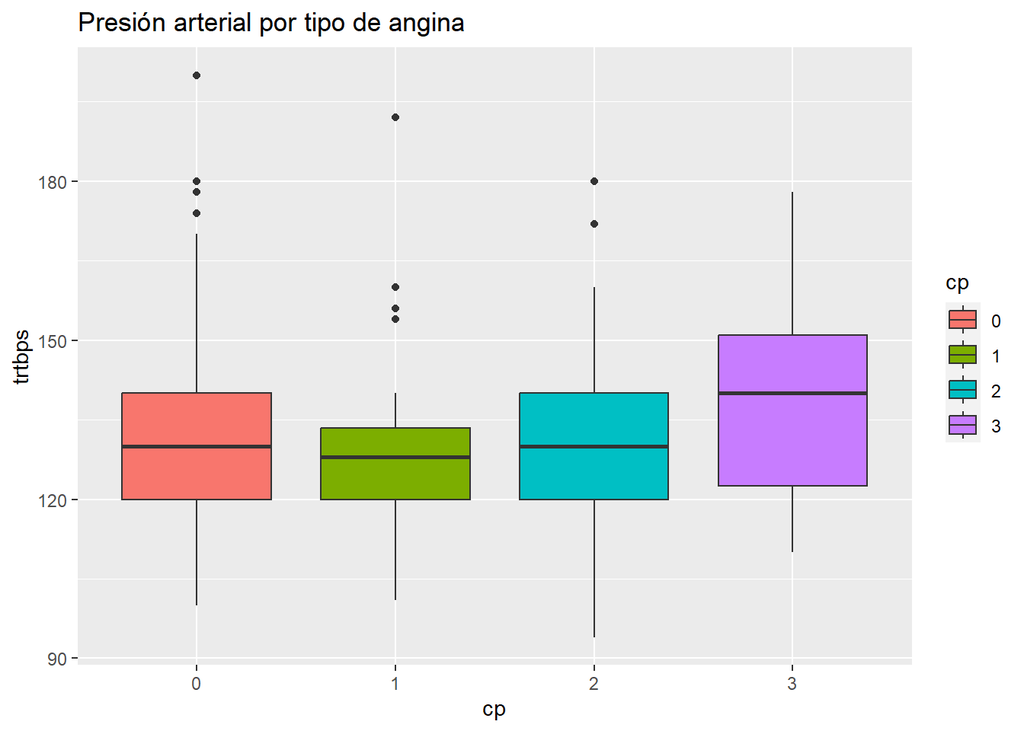

```r
ggplot(misDatos, aes(x=cp, y=trtbps, fill=cp)) + geom_boxplot() + ggtitle("Presión arterial por tipo de angina")
```

**Observación:**

- Se observa que la presión arterial es mayor cuando el tipo de angina es **dolor no anginoso**.

> El tipo de angina tiene un efecto significativo en la presión arterial cuando toma el valor *dolor no anginoso*.

## 4.5 Regresión logística multivariante

Para finalizar este apartado se analizará ¿Cómo influyen la edad, el sexo, el colesterol, la presión arterial y la glucemia en los ataques cardíacos?

Lo primero es dividir el conjunto de datos dos subconjuntos uno para entrenamiento y otro para prueba.

```r
set.seed(123)
idx <- sample(1:nrow(misDatos),nrow(misDatos)*0.8)
#conjunto de entrenamiento
train <- misDatos[idx,]
#conjunto de prueba
test <- misDatos[-idx,]
#revisión de la proporción de registros por clase de la variable output
round(prop.table(table(train$output)),2) #proporción en el conjunto de entrenamiento
```

```
##
##    0    1
## 0.45 0.55
```

```r
round(prop.table(table(test$output)),2) #proporción en el conjunto de prueba
```

```
##
##    0    1
## 0.46 0.54
```

**Observación**

> Los conjuntos de datos de entrenamiento y prueba mantienen las mismas proporciones que el conjunto de datos original para las dos clases de la variable respuesta (output), por tanto, son conjuntos de datos representativos.

Para continuar se creará un primer modelo con las variables: edad, sexo, colesterol, presión arterial y glucemia.

```r
#modelo 1
m1 <- glm(output ~ age + sex + chol + fbs + trtbps, binomial(link = "logit"), train)
summary(m1)
```

```
##
## Call:
## glm(formula = output ~ age + sex + chol + fbs + trtbps, family = binomial(link = "logit"),
##     data = train)
##
## Deviance Residuals:
##     Min       1Q   Median       3Q      Max
## -1.9099  -1.0240   0.5243   1.0226   1.8081
##
## Coefficients:
##              Estimate Std. Error z value Pr(>|z|)
## (Intercept)  6.895237   1.449725   4.756 1.97e-06 ***
## age         -0.052697   0.017203  -3.063  0.00219 **
## sex1        -1.519576   0.338318  -4.492 7.07e-06 ***
## chol        -0.003771   0.002763  -1.365  0.17233
## fbs1         0.149729   0.381639   0.392  0.69481
## trtbps      -0.013980   0.008149  -1.716  0.08624 .
## ---
## Signif. codes:  0 '***' 0.001 '**' 0.01 '*' 0.05 '.' 0.1 ' ' 1
##
## (Dispersion parameter for binomial family taken to be 1)
##
##     Null deviance: 333.48  on 241  degrees of freedom
## Residual deviance: 295.73  on 236  degrees of freedom
## AIC: 307.73
##
## Number of Fisher Scoring iterations: 3
```

**observaciones**

- se observa que las variables *edad (age)* y *sexo (sex)* son significativas su **valor p** es menor a **0.01** y **0.001** respectivamente. En cuanto a las variables *colesterol (chol)*, *presión arterial (trtbps)* y la *glucemia (fbs)* no son significativas *por lo que deben ser eliminadas del modelo*.

> Las variables nivel de colesterol, presión arterial y glucemia no tienen un efecto significativo en la predicción de sufrir ataques cardíacos.

Para continuar se añadirán al modelo anterior las variables de *tipo de angina (cp)*, *resultado del electrocardiograma (restecg)* y el *número de coronarias obstruidas (caa)*

```r
m2 <- glm(output ~ age + sex + cp + restecg + caa, binomial(link = "logit"), train)
summary(m2)
```

```
##
## Call:
## glm(formula = output ~ age + sex + cp + restecg + caa, family = binomial(link = "logit"),
##     data = train)
##
## Deviance Residuals:
##     Min       1Q   Median       3Q      Max
## -2.1635  -0.6451   0.2337   0.6762   2.5857
##
## Coefficients:
##               Estimate Std. Error z value Pr(>|z|)
## (Intercept)    2.60794    1.24991   2.087 0.036932 *
## age           -0.03440    0.02107  -1.633 0.102572
## sex1          -1.69298    0.41935  -4.037 5.41e-05 ***
## cp1            2.29651    0.56026   4.099 4.15e-05 ***
## cp2            1.96893    0.42941   4.585 4.54e-06 ***
## cp3            1.97782    0.58424   3.385 0.000711 ***
## restecg1       0.65373    0.35252   1.854 0.063674 .
## restecg2     -15.83958 1001.38355  -0.016 0.987380
## caa           -1.02885    0.22648  -4.543 5.55e-06 ***
## ---
## Signif. codes:  0 '***' 0.001 '**' 0.01 '*' 0.05 '.' 0.1 ' ' 1
##
## (Dispersion parameter for binomial family taken to be 1)
##
##     Null deviance: 333.48  on 241  degrees of freedom
## Residual deviance: 207.62  on 233  degrees of freedom
## AIC: 225.62
##
## Number of Fisher Scoring iterations: 14
```

**observaciones**

- se observa que las variables *sexo (sex)* sigue siendo significativa, sin embargo, la variable *edad (age)* deja de ser significativa.
- La variable *tipo de angina (cp)* y *número de coronarias obstruidas (caa)* también son significativas su **valor p** es menor a **0.001**. En cuanto a las variables *resultado del electrocardiograma (restecg)*, no es significativa *por lo que debe ser eliminada del modelo*.

> Las variables sexo, tipo de angina y número de coronarias obstruidas son significativas para predecir la posibilidad de sufrir un ataque cardíaco

El modelo final sería:

```r
m3 <- glm(output ~ sex + cp + caa, binomial(link = "logit"), train)
summary(m3)
```

```
##
## Call:
## glm(formula = output ~ sex + cp + caa, family = binomial(link = "logit"),
##     data = train)
##
## Deviance Residuals:
##     Min       1Q   Median       3Q      Max
## -1.9956  -0.5863   0.3264   0.6393   2.7977
##
## Coefficients:
##             Estimate Std. Error z value Pr(>|z|)
## (Intercept)   0.8573     0.3763   2.278 0.022727 *
## sex1         -1.4215     0.3887  -3.657 0.000255 ***
## cp1           2.4087     0.5452   4.418 9.95e-06 ***
## cp2           2.0482     0.4179   4.901 9.54e-07 ***
## cp3           1.7934     0.5667   3.164 0.001554 **
## caa          -1.1097     0.2182  -5.085 3.68e-07 ***
## ---
## Signif. codes:  0 '***' 0.001 '**' 0.01 '*' 0.05 '.' 0.1 ' ' 1
##
## (Dispersion parameter for binomial family taken to be 1)
##
##     Null deviance: 333.48  on 241  degrees of freedom
## Residual deviance: 217.88  on 236  degrees of freedom
## AIC: 229.88
##
## Number of Fisher Scoring iterations: 5
```

Para continuar se determinar los ODDs ratios de estas variables.

```r
#calcular el exponente de los coeficientes
round(exp(coef(m3)),2)
```

```
## (Intercept)        sex1         cp1         cp2         cp3         caa
##        2.36        0.24       11.12        7.75        6.01        0.33
```

Para continuar el análisis se validará el modelo. La clase de interés de la variable respuesta es **Probabilidad alta de ataque cardíaco** (1).

```r
#predicción de la variable respuesta
valores <- predict(m3, test, type ="response")
#si la probabilidad es mayor o igual a 0.7 entonces el paciente puede sufrir ataque cardíaco
valoresNormalizados <- ifelse(valores >= 0.7, 1,0)

#validación del modelo
real <- factor(test$output, levels = c(1,0))
prediccion <- factor(valoresNormalizados, levels = c(1,0))
#matriz de confusión
CrossTable(real,prediccion, prop.t = FALSE, prop.r= FALSE, prop.c= FALSE, prop.chisq = FALSE)
```

```
##
##
##    Cell Contents
## |-------------------------|
## |                       N |
## |-------------------------|
##
##
## Total Observations in Table:  61
##
##
##              | prediccion
##         real |         1 |         0 | Row Total |
## -------------|-----------|-----------|-----------|
##            1 |        29 |         4 |        33 |
## -------------|-----------|-----------|-----------|
##            0 |         3 |        25 |        28 |
## -------------|-----------|-----------|-----------|
## Column Total |        32 |        29 |        61 |
## -------------|-----------|-----------|-----------|
##
##
```

```r
#medidas del modelo
sensibilidad = 29/32
espeficidad = 25/29
precision = 29/33
exactidud = (29+25)/61
f1Score = 2*precision*sensibilidad/(precision+sensibilidad)
#impresión de medidas
round(c(sensibilidad,espeficidad,precision,exactidud,f1Score),2)
```

```
## [1] 0.91 0.86 0.88 0.89 0.89
```

> En resumen, el modelo tiene un rendimiento aceptable y puede utilizarse para predecir la variable de respuesta.

Finalmente, se graficará la curva ROC y se calculará el área bajo la curva.

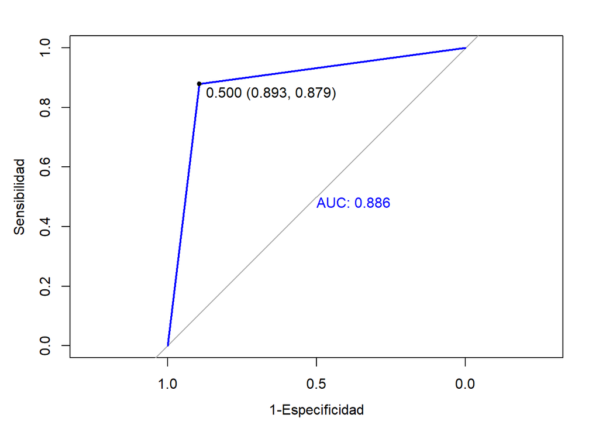

```r
library(pROC)
#calculo del roc
groc <- roc(test$output,valoresNormalizados)
#impresión del gráfico.
plot.roc(groc, print.auc=T, print.thres = "best", col="blue", xlab="1-Especificidad", ylab="Sensibilidad")
```

**Observaciones**

- El área bajo la curva (AUC) es mayor a 0.886, esto significa que el **modelo discrimina bastante bien**.
- El punto de corte (0.893, 0.879) es el que proporciona mejor balance entre la sensibilidad y la tasa de falsos positivos (1-especificidad)

> Se refuerza la conclusión que el modelo es aceptable y se puede utilizar para predecir la variable respuesta.

```r
#Guardar la base datos final
write.csv(misDatos, "data/heart_clean.csv", row.names = FALSE)
```

# 5 Resolución del problema

**Conclusiones:**

Los resultados permiten responder al problema planteado de predecir la probabilidad de sufrir un ataque cardíaco. El modelo de regresión logística final mostró un buen rendimiento en la predicción, con una alta sensibilidad y especificidad. Sin embargo, es importante tener en cuenta que estos resultados se basan en el conjunto de datos utilizado y pueden variar en diferentes poblaciones o contextos. Es recomendable validar el modelo en nuevos conjuntos de datos antes de su aplicación en la práctica clínica.